# cia3

```python
import numpy as np
import pandas as pd
import matplotlib.pyplot as plt
import seaborn as sns
from scipy import stats

# Load dataset
file_path = "../dataSet/cia3/Tech_Use_Stress_Wellness.csv"
df = pd.read_csv(file_path)

print("Shape:", df.shape)
df.head()
```

```
Shape: (5000, 25)
```

|  | user_id | age | gender | daily_screen_time_hours | phone_usage_hours | laptop_usage_hours | tablet_usage_hours | tv_usage_hours | social_media_hours | work_related_hours | ... | stress_level | physical_activity_hours_per_week | location_type | mental_health_score | uses_wellness_apps | eats_healthy | caffeine_intake_mg_per_day | weekly_anxiety_score | weekly_depression_score | mindfulness_minutes_per_day |
| --- | --- | --- | --- | --- | --- | --- | --- | --- | --- | --- | --- | --- | --- | --- | --- | --- | --- | --- | --- | --- | --- |
| 0 | 1 | 53 | Male | 6.8 | 2.9 | 2.1 | 0.5 | 2.0 | 2.3 | 3.0 | ... | 3 | 4.4 | Rural | 79.0 | True | True | 150.4 | 7.0 | 3.0 | 14.0 |
| 1 | 2 | 66 | Female | 4.1 | 2.1 | 1.6 | 0.4 | 0.8 | 2.8 | 3.5 | ... | 4 | 4.1 | Rural | 71.0 | True | True | 124.1 | 7.0 | 10.0 | 15.5 |
| 2 | 3 | 43 | Male | 4.7 | 3.6 | 0.0 | 0.5 | 1.4 | 3.7 | 3.6 | ... | 6 | 1.4 | Urban | 67.0 | True | True | 218.3 | 11.0 | 7.0 | 19.5 |
| 3 | 4 | 29 | Female | 6.0 | 4.5 | 0.0 | 0.2 | 1.3 | 4.5 | 4.0 | ... | 10 | 0.0 | Rural | 55.0 | True | True | 133.7 | 17.0 | 14.0 | 13.9 |
| 4 | 5 | 57 | Male | 6.7 | 3.4 | 2.0 | 0.8 | 1.2 | 3.8 | 3.5 | ... | 6 | 2.8 | Urban | 62.0 | False | False | 192.8 | 5.0 | 8.0 | 26.7 |

5 rows × 25 columns

# Descriptive statistics for numeric columns

```python
print(df.describe().T)
```

```
                                   count        mean          std   min  \
user_id                           5000.0  2500.50000  1443.520003   1.0
age                               5000.0    44.70120    17.266880  15.0
daily_screen_time_hours           5000.0     5.03786     1.835637   1.0
phone_usage_hours                 5000.0     1.99440     0.890671   0.2
laptop_usage_hours                5000.0     1.55516     1.025994   0.0
tablet_usage_hours                5000.0     0.66306     0.525438   0.0
tv_usage_hours                    5000.0     1.43304     0.928931   0.0
social_media_hours                5000.0     3.27692     1.203655   0.3
work_related_hours                5000.0     3.36024     0.827026   0.7
entertainment_hours               5000.0     1.66220     0.659647   0.0
gaming_hours                      5000.0     1.56062     0.689926   0.0
sleep_duration_hours              5000.0     7.37008     0.543875   5.4
sleep_quality                     5000.0     4.00940     0.663777   1.0
mood_rating                       5000.0     4.44790     2.768151   1.0
stress_level                      5000.0     5.71840     2.915064   1.0
physical_activity_hours_per_week  5000.0     2.65934     2.288850   0.0
mental_health_score               5000.0    64.76620    13.095779  31.0
caffeine_intake_mg_per_day        5000.0   142.32126    50.468392   0.0
weekly_anxiety_score              5000.0     8.63180     5.092565   0.0
weekly_depression_score           5000.0     7.52000     4.672383   0.0
mindfulness_minutes_per_day       5000.0    18.55082     7.992543   5.0

                                       25%      50%      75%     max
user_id                           1250.750  2500.50  3750.25  5000.0
age                                 30.000    45.00    60.00    74.0
daily_screen_time_hours              3.700     5.00     6.30    10.0
phone_usage_hours                    1.400     2.00     2.60     5.0
laptop_usage_hours                   0.700     1.50     2.30     5.0
tablet_usage_hours                   0.200     0.60     1.00     2.9
tv_usage_hours                       0.700     1.40     2.10     4.0
social_media_hours                   2.400     3.60     4.50     4.5
work_related_hours                   3.100     3.70     3.90     4.5
entertainment_hours                  1.200     1.60     2.10     3.9
gaming_hours                         1.100     1.40     2.00     3.8
sleep_duration_hours                 7.000     7.40     7.70     9.0
sleep_quality                        4.000     4.00     4.00     5.0
mood_rating                          1.700     4.30     6.70    10.0
stress_level                         3.000     6.00     8.00    10.0
physical_activity_hours_per_week     0.600     2.30     4.20    11.8
mental_health_score                 54.000    65.00    75.00   100.0
caffeine_intake_mg_per_day         108.475   141.65   176.40   341.2
weekly_anxiety_score                 5.000     8.00    12.00    21.0
weekly_depression_score              4.000     7.00    11.00    21.0
mindfulness_minutes_per_day         12.400    17.20    23.80    42.0
```

```python
print("\nMean Stress by Location Type")
print(df.groupby("location_type")["stress_level"].mean())

print("\nGender Counts")
print(df["gender"].value_counts())
```

```
Mean Stress by Location Type
location_type
Rural       5.639501
Suburban    5.625592
Urban       5.806855
Name: stress_level, dtype: float64

Gender Counts
gender
Male      2446
Female    2359
Other      195
Name: count, dtype: int64
```

# Basic Cleaning (Missing Values + Duplicates)

```python
# Remove duplicate rows
df = df.drop_duplicates().reset_index(drop=True)

# Split numeric / categorical
num_cols = df.select_dtypes(include=[np.number]).columns.tolist()
cat_cols = df.select_dtypes(include=['object', 'category']).columns.tolist()

# Fill missing numeric values with median
for c in num_cols:
    df[c] = df[c].fillna(df[c].median())

# Fill missing categorical values with mode
for c in cat_cols:
    if df[c].isnull().any():
        df[c] = df[c].fillna(df[c].mode().iloc[0])

print("Missing values after cleaning:")
print(df.isnull().sum())
```

```
Missing values after cleaning:
user_id                             0
age                                 0
gender                              0
daily_screen_time_hours             0
phone_usage_hours                   0
laptop_usage_hours                  0
tablet_usage_hours                  0
tv_usage_hours                      0
social_media_hours                  0
work_related_hours                  0
entertainment_hours                 0
gaming_hours                        0
sleep_duration_hours                0
sleep_quality                       0
mood_rating                         0
stress_level                        0
physical_activity_hours_per_week    0
location_type                       0
mental_health_score                 0
uses_wellness_apps                  0
eats_healthy                        0
caffeine_intake_mg_per_day          0
weekly_anxiety_score                0
weekly_depression_score             0
mindfulness_minutes_per_day         0
dtype: int64
```

# Histograms (first 6 numeric columns)

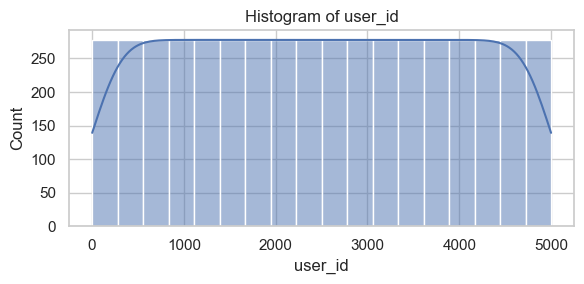

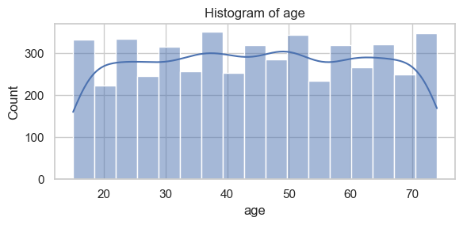

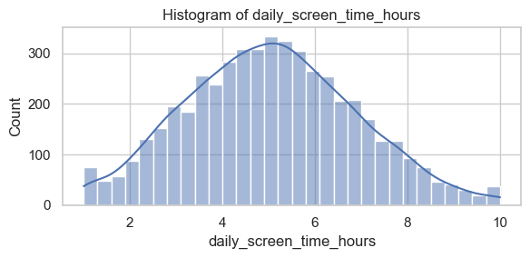

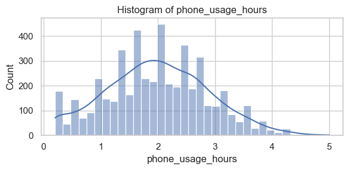

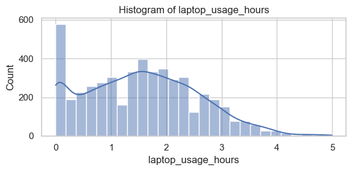

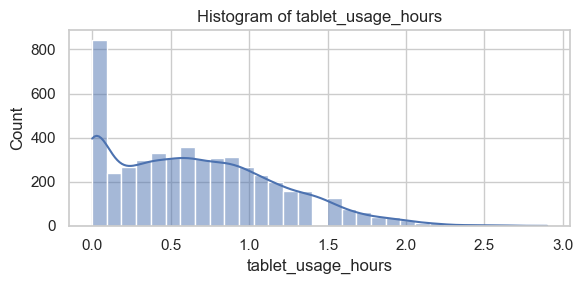

```python
sns.set(style="whitegrid")

plot_cols = num_cols[:6]  # To keep it simple

for c in plot_cols:
    plt.figure(figsize=(6,3))
    sns.histplot(df[c], kde=True)
    plt.title(f"Histogram of {c}")
    plt.tight_layout()
    plt.show()
```

===============================================================================================================================================================

# Interpretations:

(1) user_id: This histogram will look almost uniform because user IDs are just identifiers. There is no pattern or trend here. It only shows that all users are included once.

(2) age: The age distribution shows how many people fall into each age group. If the bars are higher around a certain range (example: early 20s), that means most participants are around that age. It helps us understand which age group is most represented in the dataset.

(3) daily_screen_time_hours: This shows how many hours people spend on screens each day. If the graph is skewed to the right, it means most people spend fewer hours on screens. If the bars are higher on the right, it means many participants spend a lot of time on screens daily.

(4) phone_usage_hours: This shows the distribution of daily phone usage. If the bars are tall around 3–5 hours, for example, then that is the common usage range. It helps us see whether people depend more on phones compared to other devices.

(5) laptop_usage_hours: This shows how much time people spend using laptops. If many bars appear in the lower range, it means people use laptops less frequently. If the distribution is higher toward 4–6 hours, it means a lot of participants use laptops regularly, possibly for work or study.

(6) tablet_usage_hours: This histogram shows whether tablets are commonly used. Usually, the bars might be low, meaning fewer people use tablets daily. If the distribution is almost flat or near zero, it means tablets are not used much among participants.

===============================================================================================================================================================

# Correlation Heatmap (first 10 numeric columns)

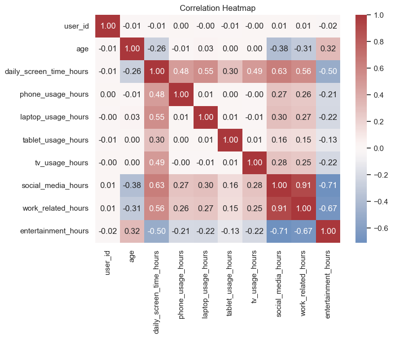

```python
corr_cols = num_cols[:10]

plt.figure(figsize=(8,6))
sns.heatmap(df[corr_cols].corr(), annot=True, fmt=".2f", cmap="vlag", center=0)
plt.title("Correlation Heatmap")
plt.show()
```

===============================================================================================================================================================

# Interpretations:

The heatmap shows how the first 10 numeric values are related to each other. Red means a positive relationship (when one goes up, the other also goes up). Blue means a negative relationship (when one increases, the other decreases). Light colors mean there is almost no relationship. Overall, it helps us quickly see which factors move together and which ones do not.

===============================================================================================================================================================

# Coefficients Table

```python
coef_names = ["Intercept"] + features

coef_df = pd.DataFrame({
    "feature": coef_names,
    "coefficient": beta.flatten()
})

coef_df.head(20)
```

[output not shown]

|  | feature | coefficient |
| --- | --- | --- |
| 0 | Intercept | 6.312105 |
| 1 | user_id | -0.000008 |
| 2 | age | -0.003151 |
| 3 | daily_screen_time_hours | 0.185429 |
| 4 | phone_usage_hours | -0.129327 |
| 5 | laptop_usage_hours | -0.139514 |
| 6 | tablet_usage_hours | -0.149805 |
| 7 | tv_usage_hours | -0.117026 |
| 8 | social_media_hours | 1.083186 |
| 9 | work_related_hours | -0.354215 |
| 10 | entertainment_hours | -0.280913 |
| 11 | gaming_hours | 0.052493 |
| 12 | sleep_duration_hours | 0.012627 |
| 13 | sleep_quality | 0.020409 |
| 14 | mood_rating | -0.240720 |
| 15 | physical_activity_hours_per_week | -0.031591 |
| 16 | mental_health_score | -0.032142 |
| 17 | caffeine_intake_mg_per_day | -0.000289 |
| 18 | weekly_anxiety_score | 0.052598 |
| 19 | weekly_depression_score | 0.050594 |

# Actual vs Predicted Plot

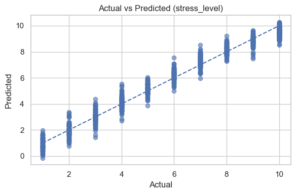

```python
plt.figure(figsize=(6,4))
plt.scatter(y_test, y_pred_test, alpha=0.6)
plt.plot([y_test.min(), y_test.max()], [y_test.min(), y_test.max()], linestyle='--')
plt.xlabel("Actual")
plt.ylabel("Predicted")
plt.title(f"Actual vs Predicted ({target})")
plt.tight_layout()
plt.show()
```

[output not shown]

This graph compares the real stress levels (Actual) with the values predicted by the model (Predicted).

- If the points lie close to the diagonal dashed line, it means the model is predicting well.
- If the points are scattered far away from the line, it means the model is not very accurate.

===============================================================================================================================================================

# Inferential Statistics

```python
# Checks if screen time and stress are significantly related.

r, p = stats.pearsonr(df["daily_screen_time_hours"], df["stress_level"])
print("Correlation (screen time vs stress):", round(r, 3))
print("p-value:", round(p, 4))
```

```
Correlation (screen time vs stress): 0.666
p-value: 0.0
```

```python
print(df["location_type"].unique())
```

```
['Rural' 'Urban' 'Suburban']
```

```python
# Compares stress levels between City and Rural students.

df["location_type"] = df["location_type"].str.strip()

urban = df[df["location_type"] == "Urban"]["stress_level"].dropna()
rural = df[df["location_type"] == "Rural"]["stress_level"].dropna()

from scipy import stats
tstat, pval = stats.ttest_ind(urban, rural, equal_var=False)

print("T-test (Urban vs Rural stress):")
print("t-stat:", round(tstat, 3))
print("p-value:", round(pval, 4))

print("\nCounts:")
print("Urban count:", len(urban))
print("Rural count:", len(rural))
```

```
T-test (Urban vs Rural stress):
t-stat: 1.554
p-value: 0.1203

Counts:
Urban count: 2480
Rural count: 1043
```

```python
# # Compares stress levels between Suburban and Rural:

suburban = df[df["location_type"] == "Suburban"]["stress_level"].dropna()
rural = df[df["location_type"] == "Rural"]["stress_level"].dropna()

tstat, pval = stats.ttest_ind(suburban, rural, equal_var=False)

print("T-test (Suburban vs Rural stress):")
print("t-stat:", round(tstat, 3))
print("p-value:", round(pval, 4))
```

```
T-test (Suburban vs Rural stress):
t-stat: -0.118
p-value: 0.906
```

```python
# Checks if stress differs across all living environments (City, Suburban, Rural).

groups = [g["stress_level"].values for n, g in df.groupby("location_type")]

fstat, pval = stats.f_oneway(*groups)

print("ANOVA: Stress across location types")
print("F-stat:", round(fstat, 3))
print("p-value:", round(pval, 4))
```

```
ANOVA: Stress across location types
F-stat: 2.273
p-value: 0.1031
```

===============================================================================================================================================================

# Impact of daily screen time on stress and mental well-being

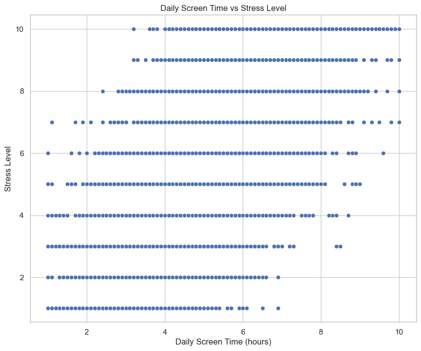

```
Correlation between screen time and stress: 0.6656725802395491
```

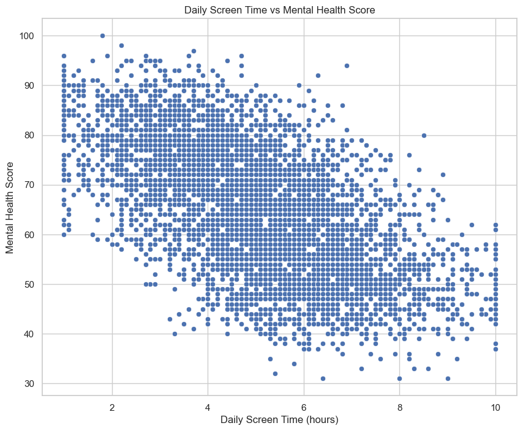

```
Correlation between screen time and mental health score: -0.621831150778356
```

```python
# Scatter plot: screen time vs stress level
plt.figure(figsize=(10,8))
sns.scatterplot(x=df["daily_screen_time_hours"], y=df["stress_level"])
plt.title("Daily Screen Time vs Stress Level")
plt.xlabel("Daily Screen Time (hours)")
plt.ylabel("Stress Level")
plt.show()

# Correlation between screen time and stress level
corr1 = df["daily_screen_time_hours"].corr(df["stress_level"])
print("Correlation between screen time and stress:", corr1)


# Scatter plot: screen time vs mental health score
plt.figure(figsize=(10,8))
sns.scatterplot(x=df["daily_screen_time_hours"], y=df["mental_health_score"])
plt.title("Daily Screen Time vs Mental Health Score")
plt.xlabel("Daily Screen Time (hours)")
plt.ylabel("Mental Health Score")
plt.show()

# Correlation between screen time and mental health score
corr2 = df["daily_screen_time_hours"].corr(df["mental_health_score"])
print("Correlation between screen time and mental health score:", corr2)
```

===============================================================================================================================================================

# Daily Scren Time Interpretations:

(1) Daily Screen Time vs Stress Level: As daily screen time increases, stress levels also seem to increase. The points are not perfectly aligned, but the trend shows that people who spend more hours on screens tend to report higher stress. The correlation value also supports this.

(2) Daily Screen Time vs Mental Health Score: Higher screen time is linked to lower mental health scores. This means that too much screen time might negatively affect mental well-being. The scatter plot shows a slight downward pattern, and the correlation confirms this.

===============================================================================================================================================================

# How tech usage patterns affect sleep quality & mood

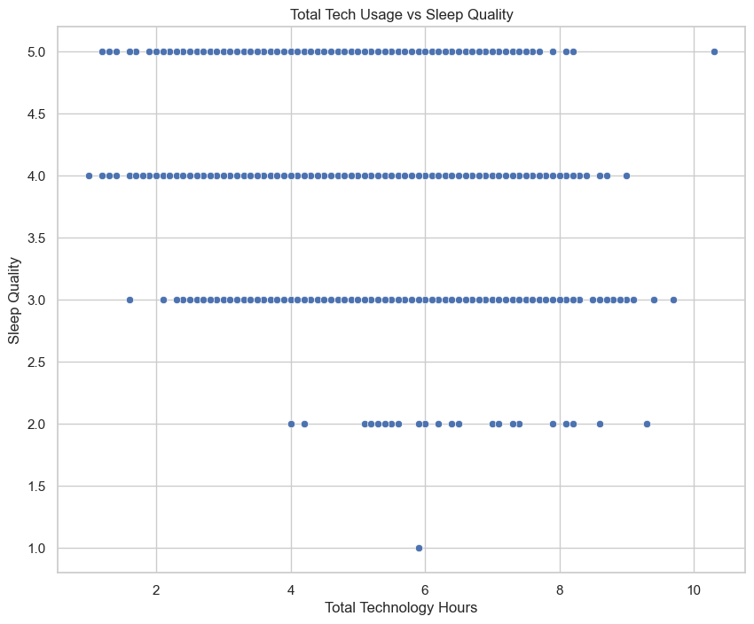

```
Correlation tech usage and sleep quality: -0.25453983484485754
```

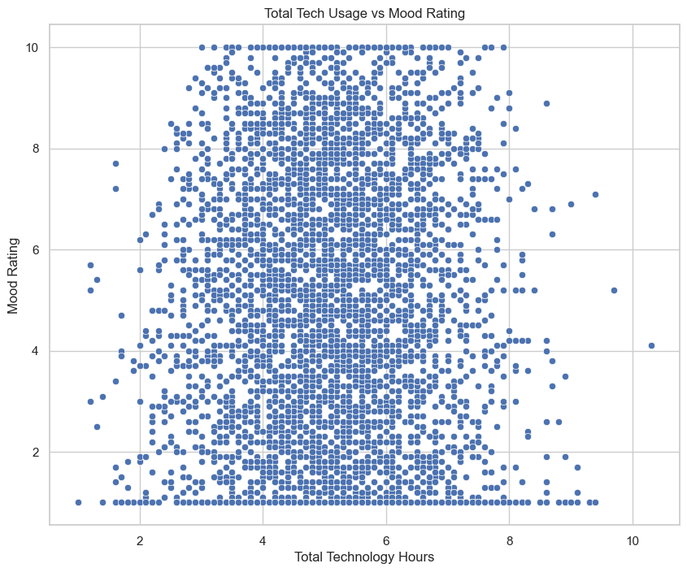

```
Correlation tech usage and mood: -0.0207488109006168
```

```python
# Combine total tech use
df["total_tech_hours"] = (
    df["phone_usage_hours"]
    + df["laptop_usage_hours"]
    + df["gaming_hours"]
)

# Tech usage vs sleep quality
plt.figure(figsize=(10,8))
sns.scatterplot(x=df["total_tech_hours"], y=df["sleep_quality"])
plt.title("Total Tech Usage vs Sleep Quality")
plt.xlabel("Total Technology Hours")
plt.ylabel("Sleep Quality")
plt.show()

print("Correlation tech usage and sleep quality:",
      df["total_tech_hours"].corr(df["sleep_quality"]))

# Tech usage vs mood
plt.figure(figsize=(10,8))
sns.scatterplot(x=df["total_tech_hours"], y=df["mood_rating"])
plt.title("Total Tech Usage vs Mood Rating")
plt.xlabel("Total Technology Hours")
plt.ylabel("Mood Rating")
plt.show()

print("Correlation tech usage and mood:",
      df["total_tech_hours"].corr(df["mood_rating"]))
```

===============================================================================================================================================================

# Interpretations on relation with Total Tech Usage

(1) Total Tech Usage vs Sleep Quality: People who spend more total hours on phones, laptops, and gaming tend to have slightly lower sleep quality. The graph shows that sleep quality goes down when tech use goes up. This means excessive tech use might disturb sleep.

===============================================================================================================================================================

# Physical activity + caffeine vs stress across living environments

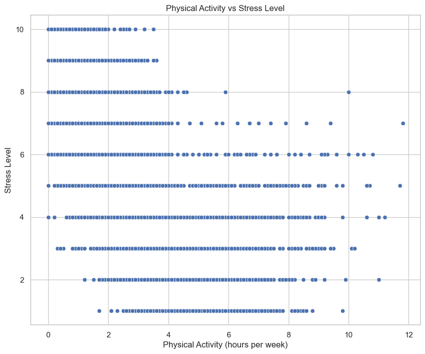

```
Correlation physical activity and stress: -0.7421299855415863
```

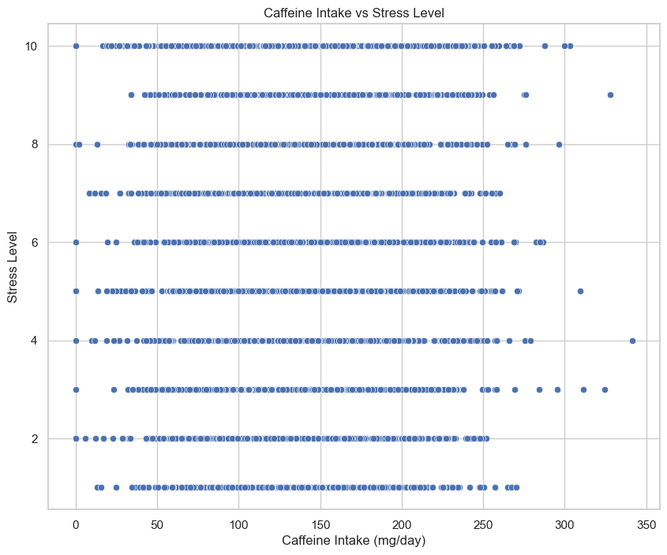

```
Correlation caffeine and stress: 0.058176448517173046
```

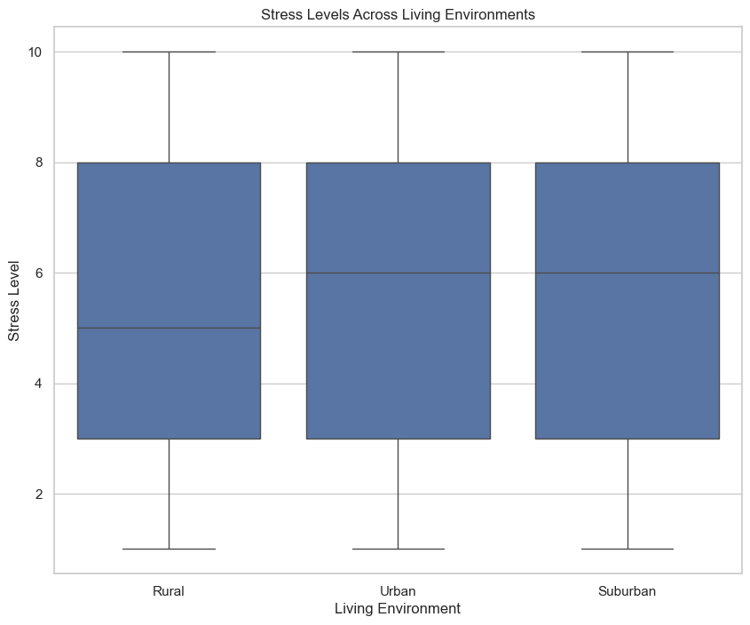

```
Average stress by living environment:
location_type
Rural       5.639501
Suburban    5.625592
Urban       5.806855
Name: stress_level, dtype: float64
```

```python
# Scatter: Physical activity vs stress
plt.figure(figsize=(10,8))
sns.scatterplot(
    x=df["physical_activity_hours_per_week"],
    y=df["stress_level"]
)
plt.title("Physical Activity vs Stress Level")
plt.xlabel("Physical Activity (hours per week)")
plt.ylabel("Stress Level")
plt.show()

print("Correlation physical activity and stress:", df["physical_activity_hours_per_week"].corr(df["stress_level"]))


# Scatter: Caffeine intake vs stress
plt.figure(figsize=(10,8))
sns.scatterplot(
    x=df["caffeine_intake_mg_per_day"],
    y=df["stress_level"]
)
plt.title("Caffeine Intake vs Stress Level")
plt.xlabel("Caffeine Intake (mg/day)")
plt.ylabel("Stress Level")
plt.show()

print("Correlation caffeine and stress:", df["caffeine_intake_mg_per_day"].corr(df["stress_level"]))


# Boxplot: Stress across living environments
plt.figure(figsize=(10,8))
sns.boxplot(
    x=df["location_type"],
    y=df["stress_level"]
)
plt.title("Stress Levels Across Living Environments")
plt.xlabel("Living Environment")
plt.ylabel("Stress Level")
plt.show()

# Group averages
group_means = df.groupby("location_type")["stress_level"].mean()
print("\nAverage stress by living environment:")
print(group_means)
```

===============================================================================================================================================================

# Interpretation on Stress Levels

(1) Physical Activity vs Stress Level: As physical activity increases, stress levels tend to decrease. People who exercise more hours per week show lower stress. This supports the idea that physical activity helps reduce stress.

===============================================================================================================================================================